# Marketing & Sales Data Predictive Modeling

# Disclaimer

This project is a sole work of [**Mohammad Adi Amirudin**](https://github.com/addiamir), any comments, pull requests, or critics can be addressed via email to amirudin.adi@gmail.com. This project is for educational purpose only and not commercial purposed. The dataset used in this project is the proprietary of the dataset owner **Hariman Samuel Saragih**.

# Project Details

## 1.1. Data Description

This project uses **Dummy Data HSS.csv** from [**Hariman Samuel Saragih**](https://www.kaggle.com/harrimansaragih) Kaggle dataset, the data contains 4572 observations of dummy marketing channel sales as presented below:

| TV | Radio | Social.Media | Influencer | Sales |
| --- | --- | --- | --- | --- |
| 16 | 6.566231 | 2.907983 | Mega | 54.73276 |
| 13 | 9.237765 | 2.409567 | Mega | 46.67790 |
| 41 | 15.886446 | 2.913410 | Mega | 150.17783 |
| 83 | 30.020028 | 6.922304 | Mega | 298.24634 |
| 15 | 8.437408 | 1.405998 | Micro | 56.59418 |
| 29 | 9.614382 | 1.027163 | Mega | 105.88915 |

## 1.2. Problem Case

Imagine that this is your company’s marketing channel data in respect to its sales. The first to fourth columns is the spending of each marketing channels, (for example in row 1, the spending for **TV** is 16, **Radio** is 6.566231, so on) while the fifth (**Sales**) is the respective sales of the company.

Your job (**Mohammad Adi Amirudin**) as the company’s hypothetical Data Analyst is to gain insight about the relationship and makes the calculations which one is **the most influential marketing channel** (`TV`, `Radio`, `Social.Media`, `Influencer`), also, the company’s Marketing Manager wants to know **how can they increase their sales to a minimum of 75% of their current sales**.

## 1.3. Project Goals

After examining what kind of results the Marketing Manager expect, you lists down several goals of this project, which are:

1. To get a general overview of the current marketing channels to `Sales`.
2. To give insights and prediction about the right combination of the upper quartile of sales (75% higher).
3. To find which marketing channel is the most important variable contributing to `Sales`.

# Preparations

This part of the project will talk about the preparation of the data, from importing dataset and libraries, data wrangling (data integrity checking, outlier and missing value treatment), data format correction, and train-test data.frame splitting.

## 2.1. Importing Dataset & Library

```r
# Loading Dataset
datamrkt <- read.csv("D:/1. Active Projects/Data Analysis/Personal Projects Directory/Marketing & Sales Data Predictive Modeling/Dummy Data HSS.csv")
# Loading Libraries Required
library(dplyr)
library(tidyr)
library(caret)
library(ggplot2)
library(psych)
library(mice)
library(InformationValue)
library(ROSE)
library(rpart)
library(stats)
library(randomForest)
library(gridExtra)
library(highcharter)
library(prettydoc)
```

## 2.2. Data Wrangling

### 2.2.1. Preliminary Look at The Data

Before we delve into some analysis, it is crucial to look at the data and examines its features, as well as making some-if necessary-adjustments. We will start with inspecting the data first.

```r
summary(datamrkt)
```

```
       TV             Radio           Social.Media        Influencer
 Min.   : 10.00   Min.   : 0.00068   Min.   : 0.000031   Length:4572
 1st Qu.: 32.00   1st Qu.:10.52596   1st Qu.: 1.527849   Class :character
 Median : 53.00   Median :17.85951   Median : 3.055565   Mode  :character
 Mean   : 54.07   Mean   :18.16036   Mean   : 3.323956
 3rd Qu.: 77.00   3rd Qu.:25.64973   3rd Qu.: 4.807558
 Max.   :100.00   Max.   :48.87116   Max.   :13.981662
 NA's   :10       NA's   :4          NA's   :6
     Sales
 Min.   : 31.2
 1st Qu.:112.3
 Median :189.2
 Mean   :192.5
 3rd Qu.:272.5
 Max.   :364.1
 NA's   :6
```

From this summary, we can tell that our data has missing values (NA’s value in all variables except for `Influencer`). The `Influencer` variable also presented as `class:: character`, which is wrong, considering that `Influencer` variable explains the types of influencers used (**Mega**, **Macro**, **Micro**, **Nano**) therefore its data type should be factors not characters. Another problem that we might be having is outliers, we will sort this problem out using the following outlier moderation.

```r
datamrkt$Influencer <- as.factor(datamrkt$Influencer)
is.factor(datamrkt$Influencer)
```

```
[1] TRUE
```

This little block of code can help us to change the `Influencer` wrong data type.

### 2.2.2. Missing Values Treatment

```r
sum(is.na(datamrkt))
```

```
[1] 26
```

```r
mean(is.na(datamrkt))
```

```
[1] 0.001137358
```

The code explains that we had 26 (0.113%) missing values. To deal with the missing values, we can choose whether to omit the missing values, makes an iteration (creating new values), or just leaving it up.

**1. Leave them be**

Since the business spending on every marketing channels; **TV**, **Radio**, **Social.Media**, even on **Sales**, the probability of the actual value is 0 is unlikely, thus, keeping the missing values to the dataset will not giving any insights.

**2. Iteration with stochastic regression**

Another way is to iterate or *‘create’* the values that projected to the missing values. But then, there is a caveat on this approach, we can’t just make up for every bit of missing values because it may caused biasedness in the analysis later, since the data has been modified so much.

```r
imp <- mice(datamrkt, method = "norm.nob", m = 1)  #Impute data
Data2 <- complete(imp)  #Store data
sapply(Data2, anyNA)
```

```
          TV        Radio Social.Media   Influencer        Sales
        TRUE        FALSE        FALSE        FALSE        FALSE
```

Even after iteration, we can see that variable `TV` still has missing values (Although it can be dealt with changing the iteration method), thus we may want to look out to other safe alternatives before proceeding to further iteration.

**3. Omitted Missing Values**

```r
datamrkt <- na.omit(datamrkt)
sapply(datamrkt, anyNA)
```

```
          TV        Radio Social.Media   Influencer        Sales
       FALSE        FALSE        FALSE        FALSE        FALSE
```

Now that our missing values problem solved, we can continue the wrangling process.

### 2.2.3. Outlier Moderations

#### TV

[interactive chart not shown]

```
integer(0)
```

#### Radio

[interactive chart not shown]

```
[1] 4306
```

#### Social Media

[interactive chart not shown]

```
 [1]  135  192  443  479  533  578  842 1210 1338 1387 1443 1847 1904 2025 2066
[16] 2071 2270 2321 2393 2747 3069 3277 3475 3761 3776 4153 4254 4350
```

#### Sales

[interactive chart not shown]

```
integer(0)
```

# Analysis

## 3.1. Overview of Current Situation

In this part we will be analyzing the overview of the current company situation, which uses explanatory data analysis (EDA) method.

#### Correlation Pairs Panel

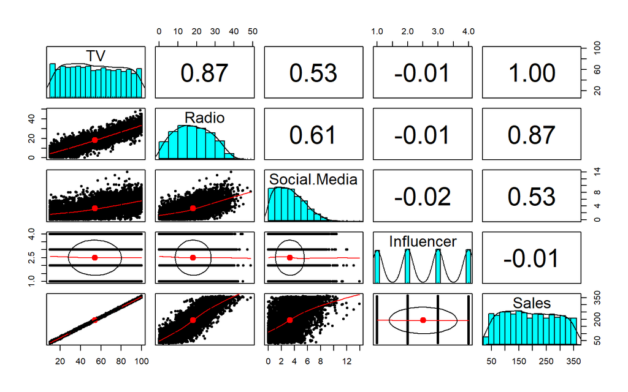

**Correlation Pairs Panel**

The pair panels is a mix of; *1. Distribution panels (lower diagonal panels)* indicate the distribution of one variable with its respective pairs, *2. Frequency Panels (diagonal panels)*, describes the frequency of each variables and *3. Pearsons Correlation (upper diagonal panels)* which indicate the correlation between one variable to another, with -/+ as a ‘negative/positive’ correlation indicator and strength varys between 0 and 1.

#### Descriptive Statistics

|  | vars | n | mean | sd | median | trimmed | mad | min | max | range | skew | kurtosis | se |
| --- | --- | --- | --- | --- | --- | --- | --- | --- | --- | --- | --- | --- | --- |
| TV | 1 | 4546 | 54.062913 | 26.104942 | 53.000000 | 53.819406 | 32.617200 | 10.0000000 | 100.00000 | 90.00000 | 0.0690698 | -1.1854534 | 0.3871756 |
| Radio | 2 | 4546 | 18.157533 | 9.663260 | 17.859513 | 17.992140 | 11.114423 | 0.0006839 | 48.87116 | 48.87048 | 0.1436178 | -0.8170952 | 0.1433207 |
| Social.Media | 3 | 4546 | 3.323473 | 2.211254 | 3.055565 | 3.159211 | 2.388219 | 0.0000313 | 13.98166 | 13.98163 | 0.6476362 | 0.0527110 | 0.0327962 |
| Influencer* | 4 | 4546 | 2.506819 | 1.112811 | 3.000000 | 2.508521 | 1.482600 | 1.0000000 | 4.00000 | 3.00000 | -0.0066074 | -1.3484188 | 0.0165047 |
| Sales | 5 | 4546 | 192.413332 | 93.019873 | 188.963678 | 191.523626 | 118.407162 | 31.1994087 | 364.07975 | 332.88034 | 0.0700223 | -1.1845258 | 1.3796249 |

## 3.2. Insights & Prediction of 3rd Quartile Sales

### 3.2.1 Methods Overview

These tabs below will gives us a glimpse about the machine learning methods as well as the evaluation parameters that being used in this marketing channel analysis.

#### Methods

To get a deeper insight to the data, and try to replicate the combination of each variables (spending on `TV`, `Social Media`, `Influencer` and `Radio`) to best sales volumes (equals to and higher than 75%) we employed *Classification Machine Learning* methods which falls under the **Supervised Machine Learning**.

##### **Logistic Regression**

`Logistic regression` predicts the output of a categorical dependent variable. Therefore the outcome must be a categorical or discrete value. It can be either Yes or No, 0 or 1, true or False, etc. but instead of giving the exact value as 0 and 1, it gives the probabilistic values which lie between 0 and 1. This method serve fits the purpose of this research, in which we will classify the **75% and above sales quantile** to be the 1 and the rest is 0.

##### **Decision Tree**

`Decision Tree` are a popular model, used in operations research, strategic planning, and machine learning. Although `Decision Tree` are intuitive and easy to build it can fall short when it comes to accuracy due to its dependency to the level of the tree leaves.

##### **Random Forest**

`Random Forest` is a further iteration of `Decision Tree`, in which combines several ‘trees’ into a ‘forest’. Since we employ ‘Decision Tree’ into our reasearch, we might as well employ `Random Forest` and calculate which methods are consider the best using Model Evaluation

##### **Two-Class Support Vector Machine**

The last method that employed is `Support Vector Machine` method. In machine learning, `Support-Vector Machines` (SVMs, also called Support-Vector Networks) are supervised learning models with associated learning algorithms that analyze data for classification and regression analysis. Given a set of training examples, each marked as belonging to one of two categories, an SVM training algorithm builds a model that assigns new examples to one category or the other, making it a non-probabilistic binary linear classifier. We emphasize the `Two-Class` in this case since the methods is commonly used for multi-class classification problems.

#### Evaluation Parameters

Model Accuracy

Confusion Matrix

## 3.3. Variable Importance